# Lectura de imágenes con OpenCV

## 1 Introducción

En esta práctica aprenderemos a leer diferentes tipos de imágenes usando **OpenCV** en Python.  
Trabajaremos en un entorno local con **Anaconda**, lo que nos permite usar bibliotecas adicionales para manejar formatos que OpenCV no soporta de forma nativa.

OpenCV soporta de forma directa formatos como:

- **JPG / JPEG**: compresión con pérdida
- **PNG**: compresión sin pérdida y canal alfa
- **TIFF**: admite profundidad de bits alta y múltiples páginas
- **BMP**: sin compresión, usado en entornos Windows

Para formatos **RAW** (archivos de cámaras digitales, como `.CR2`, `.NEF`, `.ARW`), usaremos la librería `rawpy` junto con `imageio`, ya que OpenCV no los soporta directamente.

## 2 Configuración inicial

```python
import cv2
import numpy as np
import matplotlib.pyplot as plt
import rawpy
import imageio.v2 as imageio
from pathlib import Path
from PIL import Image

# Función auxiliar para mostrar imágenes en escala de grises o color
def mostrar_img(img, titulo="Imagen", cmap=None):
    plt.figure(figsize=(5,5))
    if len(img.shape) == 2:  # Escala de grises
        plt.imshow(img, cmap='gray')
    else:  # Color (BGR a RGB para mostrar correctamente)
        plt.imshow(cv2.cvtColor(img, cv2.COLOR_BGR2RGB))
    plt.title(titulo)
    plt.axis('off')
    plt.show()
```

## 3 Lectura de imágenes comunes con OpenCV

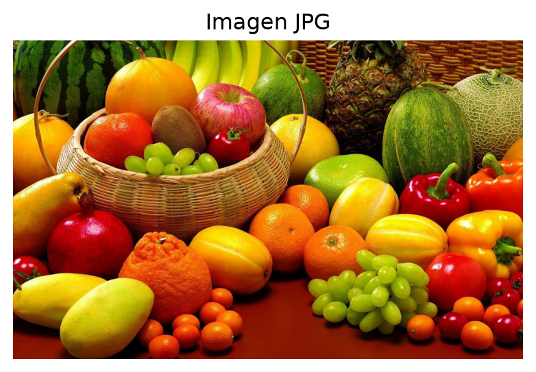

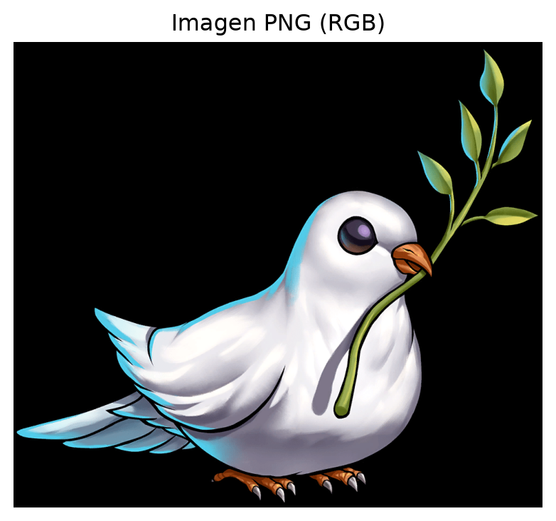

[figure not shown]

[figure not shown]

```python
# Ruta a las imágenes (ajustar según tu carpeta local)
carpeta = Path("imagenes")

# JPG
img_jpg = cv2.imread(str(carpeta / "frutas.jpg"))
mostrar_img(img_jpg, "Imagen JPG")

# PNG con canal alfa (transparencia)
img_png = cv2.imread(str(carpeta / "373-3730435_paloma-dibujo-png.png"), cv2.IMREAD_UNCHANGED)
mostrar_img(img_png[:, :, :3], "Imagen PNG (RGB)")

# TIFF en escala de grises
img_tiff = cv2.imread(str(carpeta / "DPP0357.TIF"), cv2.IMREAD_GRAYSCALE)
mostrar_img(img_tiff, "Imagen TIFF (grises)")

# TIFF en escala de color
img_tiff2 = cv2.imread(str(carpeta / "DPP0357.TIF"), cv2.IMREAD_UNCHANGED)
mostrar_img(img_tiff2, "Imagen TIFF")
```

## 4 Ejercicio: profundidad de bits y paginas TIFF

Los archivos `DPP*.TIF` del repositorio de datasets son TIFF de una sola pagina y 8 bits por canal. Por ello, sirven para practicar la lectura del formato, pero no para demostrar una profundidad alta ni una secuencia multipagina. El siguiente ejercicio crea ambos casos a partir de `DPP0357.TIF`.

```python
ruta_tiff = carpeta / "DPP0357.TIF"
img_dataset = cv2.imread(str(ruta_tiff), cv2.IMREAD_UNCHANGED)

with Image.open(ruta_tiff) as archivo_tiff:
    print(f"Paginas en {ruta_tiff.name}: {archivo_tiff.n_frames}")
    print(f"Bits por muestra: {archivo_tiff.tag_v2.get(258)}")

print(f"dtype en NumPy/OpenCV: {img_dataset.dtype}")
print(f"Rango de valores: [{img_dataset.min()}, {img_dataset.max()}]")
```

```
Paginas en DPP0357.TIF: 1
Bits por muestra: (8, 8, 8)
dtype en NumPy/OpenCV: uint8
Rango de valores: [0, 255]
```

```
dtype TIFF de 16 bits: uint16
Rango TIFF de 16 bits: [0, 65535]
```

[figure not shown]

```python
# Crear una version TIFF real de 16 bits en una carpeta de salida local.
salida = Path("salida_tiff")
salida.mkdir(exist_ok=True)

gris_8 = cv2.cvtColor(img_dataset, cv2.COLOR_BGR2GRAY)
gris_16 = gris_8.astype(np.uint16) * 257  # 0--255 se convierte en 0--65535.
ruta_16_bits = salida / "DPP0357_16bits.tiff"
Image.fromarray(gris_16).save(ruta_16_bits)

recargada_16 = cv2.imread(str(ruta_16_bits), cv2.IMREAD_UNCHANGED)
print(f"dtype TIFF de 16 bits: {recargada_16.dtype}")
print(f"Rango TIFF de 16 bits: [{recargada_16.min()}, {recargada_16.max()}]")

# Matplotlib ajusta el contraste automaticamente. Fijar el rango permite
# comparar los valores de 16 bits con una visualizacion consistente.
plt.imshow(recargada_16, cmap="gray", vmin=0, vmax=65535)
plt.title("DPP0357 convertido a TIFF de 16 bits")
plt.axis("off")
plt.show()
```

```
Paginas creadas: 3
```

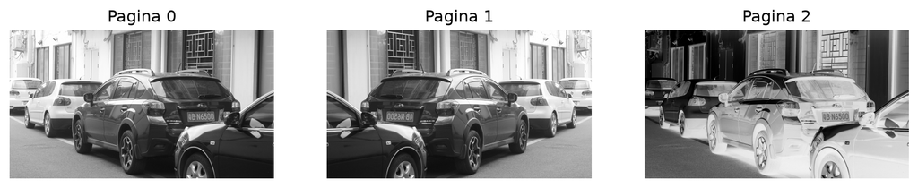

```python
# Crear y leer un TIFF multipagina: original, espejo horizontal y negativo.
paginas = [
    Image.fromarray(gris_8),
    Image.fromarray(cv2.flip(gris_8, 1)),
    Image.fromarray(255 - gris_8),
]
ruta_multipagina = salida / "DPP0357_multipagina.tiff"
paginas[0].save(ruta_multipagina, save_all=True, append_images=paginas[1:])

with Image.open(ruta_multipagina) as archivo_tiff:
    print(f"Paginas creadas: {archivo_tiff.n_frames}")
    fig, ejes = plt.subplots(1, archivo_tiff.n_frames, figsize=(12, 4))
    for indice, eje in enumerate(ejes):
        archivo_tiff.seek(indice)
        eje.imshow(np.asarray(archivo_tiff), cmap="gray", vmin=0, vmax=255)
        eje.set_title(f"Pagina {indice}")
        eje.axis("off")
    plt.show()
```

Verifica que OpenCV recarga el primer ejemplo como `uint16`. Observa tambien que las tres paginas no son canales de color: cada una es una imagen independiente dentro del mismo archivo TIFF.

## 5 Lectura de imágenes RAW

OpenCV no puede leer directamente formatos RAW de cámaras digitales. Usaremos `rawpy` para convertirlos a un arreglo NumPy.

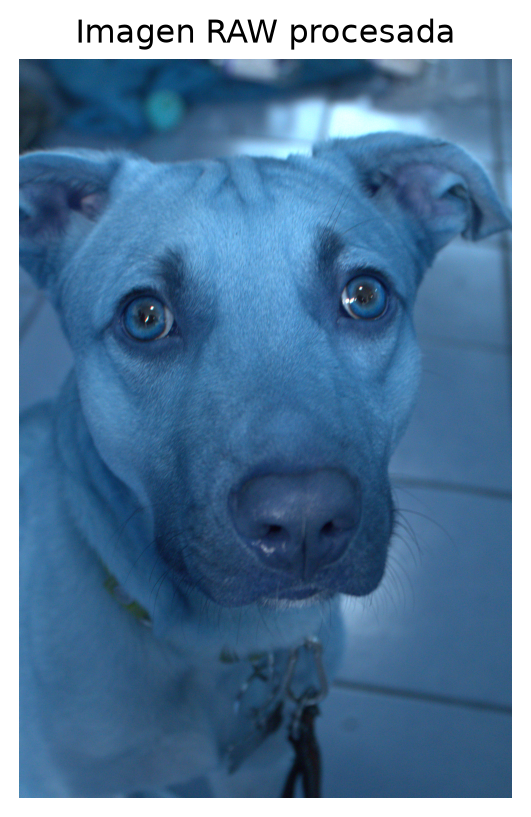

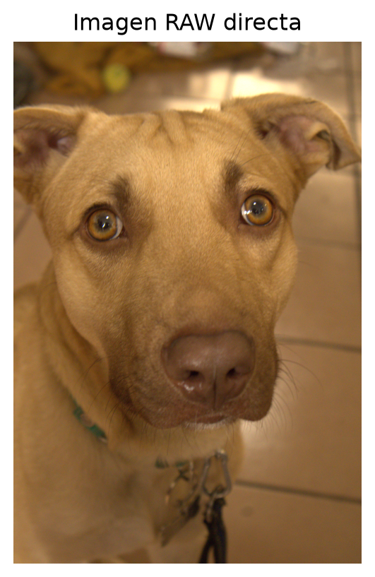

```python
# Ejemplo con un archivo RAW (CR3 de Canon, NEF de Nikon, etc.)
ruta_raw = carpeta / "IMG_0531.CR3"

with rawpy.imread(str(ruta_raw)) as raw:
    rgb = raw.postprocess()

# raw.postprocess() devuelve un arreglo RGB de 8 bits
mostrar_img(rgb, "Imagen RAW procesada")

plt.imshow(rgb)
plt.title("Imagen RAW directa")
plt.axis('off')
plt.show()
```

## 6 Notas importantes

- **Espacios de color**: OpenCV usa BGR por defecto para imágenes en color. Al mostrar con Matplotlib, es necesario convertir a RGB.
- **Canales alfa**: Si la imagen tiene transparencia (por ejemplo, PNG con 4 canales), OpenCV la carga con el canal alfa incluido si usamos `cv2.IMREAD_UNCHANGED`.
- **Compatibilidad RAW**: Los formatos RAW varían entre fabricantes; `rawpy` está basado en `libraw`, que ofrece soporte para una amplia variedad de cámaras.

## 7 Conclusión

Esto nos permite trabajar con una amplia variedad de formatos en un flujo de procesamiento digital de imágenes.